# R Notebook

### Importing Data

```r
bikeshare <- read.csv(file.choose(), header = TRUE)
```

### Enabling Libraries

```r
library(olsrr)
library(sqldf)
library(tidyverse)
library(reshape2)
```

# Exploratory Data Analysis

Here we want to take an initial look into the relationship of the different categorical and numeric variables with the hourly bike demands of the London Bike Sharing System

#### Weekday Bike Demands per Hour versus Weekend Bike Demands per Hour

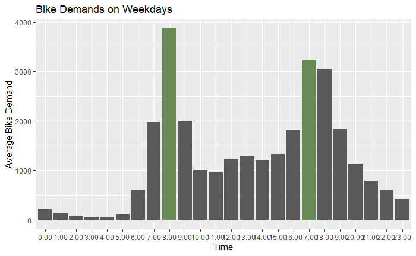

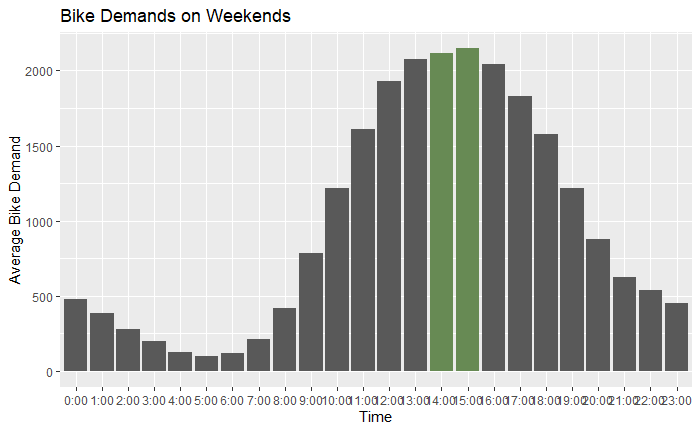

Comparing the peak hours during the weekdays versus that of the weekends, we understand why the different riders use this service. On the weekdays, the peak hours of 8AM and 5PM tell us that riders may use this to go to work or to school. On the other hand, the peak hours on the weekends may suggest that the riders use this to get around the city for leisurely activities like shopping.

#### Bike Demand Per Season

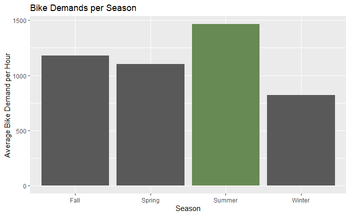

```r
season_demand <- sqldf("SELECT season, AVG(cnt) AS avg_cnt FROM bikeshare GROUP BY season")
season_demand$highlight <- with(season_demand, ifelse(season_demand$season == 1, T, F))

season_demand[season_demand == 0] <- "Spring"
season_demand[season_demand == 1] <- "Summer"
season_demand[season_demand == 2] <- "Fall"
season_demand[season_demand == 3] <- "Winter"

ggplot(data = season_demand) +
  geom_bar(mapping = aes(x = season, y = avg_cnt, fill = highlight), stat = "identity") +
  ggtitle("Bike Demands per Season") +
  labs(x = "Season", y = 'Average Bike Demand per Hour') +
  scale_fill_manual(values = c('#595959', '#678a54')) +
  theme(legend.position = 'none')
```

An understandably high usage of bikes during the summertime may tell us that the environment plays a factor in the number of active riders. With that, we may wonder if this is caused by the temperature change or possibly because of the weather conditions.

#### Bike Demand Per Weather Condition

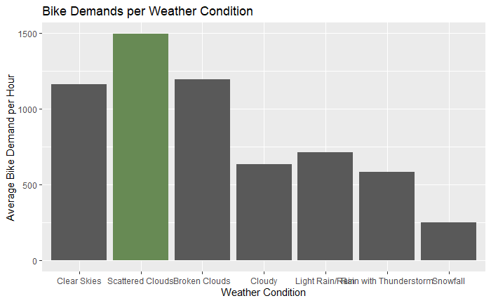

```r
weathercondi_demand <- sqldf("SELECT weather_code, AVG(cnt) AS avg_cnt FROM bikeshare GROUP BY weather_code")

weathercondi_demand[weathercondi_demand == 1] <- "Clear Skies"
weathercondi_demand[weathercondi_demand == 2] <- "Scattered Clouds"
weathercondi_demand[weathercondi_demand == 3] <- "Broken Clouds"
weathercondi_demand[weathercondi_demand == 4] <- "Cloudy"
weathercondi_demand[weathercondi_demand == 7] <- "Light Rain/Rain"
weathercondi_demand[weathercondi_demand == 10] <- "Rain with Thunderstorm"
weathercondi_demand[weathercondi_demand == 26] <- "Snowfall"
weathercondi_demand[weathercondi_demand == 94] <- "Freezing Fog"
weathercondi_demand$highlight <- with(weathercondi_demand, ifelse(weathercondi_demand$weather_code == "Scattered Clouds", T, F))

ggplot(data = weathercondi_demand) +
  geom_bar(mapping = aes(x = factor(weather_code, levels = c("Clear Skies", "Scattered Clouds", "Broken Clouds", "Cloudy", "Light Rain/Rain", "Rain with Thunderstorm", "Snowfall", "Freezing Fog")), y = avg_cnt, fill = highlight), stat = "identity") +
  ggtitle("Bike Demands per Weather Condition") +
  labs(x = "Weather Condition", y = "Average Bike Demand per Hour") +
  scale_fill_manual(values = c('#595959', '#678a54')) +
  theme(legend.position = 'none')
```

Here we see that the most popular weather condition to bike in is if it is barely cloudy. This could be ideal considering that biking under clear skies or sunny weather may be uncomfortable to some.

#### Bike Demand According to Temperature

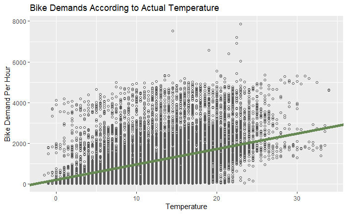

```r
t1_demand <- sqldf("SELECT t1, cnt FROM bikeshare")
t1_lm <- lm(cnt~t1, data = t1_demand)

ggplot(data = t1_demand) +
  geom_point(mapping = aes(x = t1, y = cnt), colour = '#595959', shape = 1) +
  geom_abline(slope = coef(t1_lm)[2], intercept = coef(t1_lm)[1], colour = '#678a54', linewidth = 2) +
  ggtitle('Bike Demands According to Actual Temperature') +
  labs(x = "Temperature", y = "Bike Demand Per Hour")
```

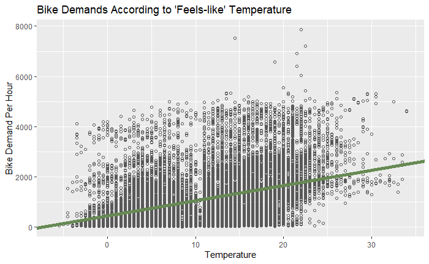

```r
t2_demand <- sqldf("SELECT t2, cnt FROM bikeshare")
t2_lm <- lm(cnt~t2, data = t2_demand)

ggplot(data = t2_demand) +
  geom_point(mapping = aes(x = t2, y = cnt), colour = '#595959', shape = 1) +
  geom_abline(slope = coef(t2_lm)[2], intercept = coef(t2_lm)[1], colour = '#678a54', linewidth = 2) +
  ggtitle("Bike Demands According to 'Feels-like' Temperature") +
  labs(x = "Temperature", y = "Bike Demand Per Hour")
```

#### Bike Demand According to Humidity

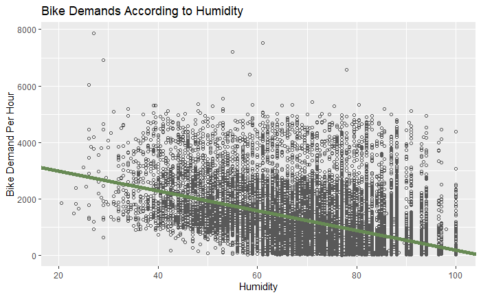

```r
hum_demand <- sqldf("SELECT hum, cnt FROM bikeshare")
hum_lm <- lm(cnt~hum, data = hum_demand)

ggplot(data = hum_demand) +
  geom_point(mapping = aes(x = hum, y = cnt), colour = '#595959', shape = 1) +
  geom_abline(slope = coef(hum_lm)[2], intercept = coef(hum_lm)[1], colour = '#678a54', linewidth = 2) +
  ggtitle('Bike Demands According to Humidity') +
  labs(x = "Humidity", y = "Bike Demand Per Hour")
```

#### Bike Demand According to Wind Speed

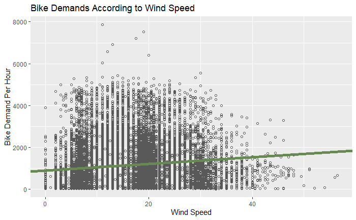

```r
windspeed_demand <- sqldf("SELECT wind_speed, cnt FROM bikeshare")
windspeed_lm <- lm(cnt~wind_speed, data = windspeed_demand)

ggplot(data = windspeed_demand) +
  geom_point(mapping = aes(x = wind_speed, y = cnt), colour = '#595959', shape = 1) +
  geom_abline(slope = coef(windspeed_lm)[2], intercept = coef(windspeed_lm)[1], colour = '#678a54', linewidth = 2) +
  ggtitle('Bike Demands According to Wind Speed') +
  labs(x = "Wind Speed", y = "Bike Demand Per Hour")
```

The graphs show us the linear relationship between the different environmental factors to bike demands. We see that there is a slightly positive relationship of bike demands with temperature (both actual and “feels-like”) while there is a stronger negative relationship with humidity. The slope of the regression function in relation to wind speed is not as prominent, which may tell us that they either have another form of relationship or that they may not be related strongly.

# Machine Learning Model (Supervised - Linear Regression)

Here we start to build our prediction model for the bike demands.

#### Separating Training and Test Data

```r
set.seed(12345)
sample <- sample(c(TRUE, FALSE), nrow(bikeshare), replace = TRUE, prob = c(0.7, 0.3))

train <- bikeshare[sample, ]
train$weather_code <- factor(train$weather_code)
train$is_weekend <- factor(train$is_weekend)
train$time <- factor(train$time, levels = c('0:00', '1:00', '2:00', '3:00', '4:00', '5:00', '6:00', '7:00', '8:00', '9:00', '10:00',
                                      '11:00', '12:00', '13:00', '14:00', '15:00', '16:00', '17:00', '18:00', '19:00', '20:00',
                                      '21:00', '22:00', '23:00'))

test <- bikeshare[!sample, ]
test$weather_code <- factor(test$weather_code)
test$is_weekend <- factor(test$is_weekend)
test$time <- factor(test$time, levels = c('0:00', '1:00', '2:00', '3:00', '4:00', '5:00', '6:00', '7:00', '8:00', '9:00', '10:00',
                                            '11:00', '12:00', '13:00', '14:00', '15:00', '16:00', '17:00', '18:00', '19:00', '20:00',
                                            '21:00', '22:00', '23:00'))
```

#### Correlation Analysis of Temperature, Humidity, Wind Speed, Weather Conditions, and Bike Demand

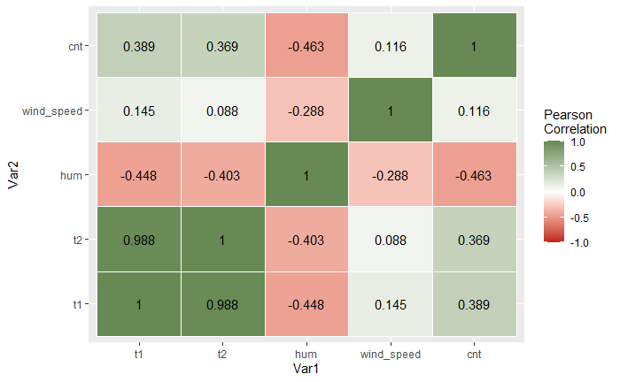

The correlation matrix shows us that the correlation among the different numerical variables that we will be using in our model is not extremely strong but there is some sort of correlation still present, which may be detrimental to our model. Aside from this, t1 and t2 have extremely high correlation as they refer to very similar factors. We will see later in our model if removing one can be beneficial to the model or not.

#### Training Model

```r
environment_lm <- lm(cnt ~ t1 + t2 + hum + wind_speed + weather_code + is_weekend + time, data = train)
summary(environment_lm)
```

```
Call:
lm(formula = cnt ~ t1 + t2 + hum + wind_speed + weather_code +
    is_weekend + time, data = train)

Residuals:
    Min      1Q  Median      3Q     Max
-2973.3  -274.7   -21.3   264.7  4238.0

Coefficients:
                Estimate Std. Error t value Pr(>|t|)
(Intercept)     968.6213    59.8538  16.183  < 2e-16 ***
t1               66.6866     7.0557   9.451  < 2e-16 ***
t2              -21.5469     5.8104  -3.708 0.000210 ***
hum             -12.4699     0.5521 -22.587  < 2e-16 ***
wind_speed      -10.1552     0.7867 -12.909  < 2e-16 ***
weather_code2    40.4918    15.0074   2.698 0.006983 **
weather_code3   -23.1162    16.2494  -1.423 0.154881
weather_code4   -34.3530    21.1341  -1.625 0.104086
weather_code7  -244.1935    19.9867 -12.218  < 2e-16 ***
weather_code10 -580.6346   168.4049  -3.448 0.000567 ***
weather_code26  173.4262    89.9325   1.928 0.053828 .
is_weekend1    -229.7199    11.7179 -19.604  < 2e-16 ***
time1:00        -53.5568    36.9835  -1.448 0.147608
time2:00       -118.7296    36.3717  -3.264 0.001100 **
time3:00       -128.4743    36.0917  -3.560 0.000373 ***
time4:00       -129.7068    36.3152  -3.572 0.000356 ***
time5:00        -90.9136    36.5564  -2.487 0.012898 *
time6:00        261.4502    36.6546   7.133 1.04e-12 ***
time7:00       1223.3070    36.1122  33.875  < 2e-16 ***
time8:00       2582.9899    36.4777  70.810  < 2e-16 ***
time9:00       1271.8226    36.3847  34.955  < 2e-16 ***
time10:00       633.0062    37.1355  17.046  < 2e-16 ***
time11:00       646.3570    37.2400  17.357  < 2e-16 ***
time12:00       886.4551    37.5966  23.578  < 2e-16 ***
time13:00       922.2481    37.4325  24.638  < 2e-16 ***
time14:00       852.8932    37.6378  22.661  < 2e-16 ***
time15:00       950.5505    37.5520  25.313  < 2e-16 ***
time16:00      1281.0127    36.9425  34.676  < 2e-16 ***
time17:00      2257.7589    37.2572  60.599  < 2e-16 ***
time18:00      2121.3653    36.8944  57.498  < 2e-16 ***
time19:00      1179.6615    36.3286  32.472  < 2e-16 ***
time20:00       628.8491    36.2642  17.341  < 2e-16 ***
time21:00       362.5369    36.1285  10.035  < 2e-16 ***
time22:00       250.6944    36.4869   6.871 6.69e-12 ***
time23:00       120.9534    36.5689   3.308 0.000944 ***
---
Signif. codes:  0 ‘***’ 0.001 ‘**’ 0.01 ‘*’ 0.05 ‘.’ 0.1 ‘ ’ 1

Residual standard error: 580.9 on 12183 degrees of freedom
Multiple R-squared:  0.7133,    Adjusted R-squared:  0.7125
F-statistic: 891.4 on 34 and 12183 DF,  p-value: < 2.2e-16
```

```r
anova(environment_lm)
```

```
Analysis of Variance Table

Response: cnt
                Df     Sum Sq    Mean Sq  F value    Pr(>F)
t1               1 2081854238 2081854238 6169.521 < 2.2e-16 ***
t2               1  139381441  139381441  413.053 < 2.2e-16 ***
hum              1 1337829931 1337829931 3964.625 < 2.2e-16 ***
wind_speed       1   10756758   10756758   31.877 1.679e-08 ***
weather_code     6  300396755   50066126  148.370 < 2.2e-16 ***
is_weekend       1  102222261  102222261  302.933 < 2.2e-16 ***
time            23 6254225176  271922834  805.836 < 2.2e-16 ***
Residuals    12183 4111053075     337442
---
Signif. codes:  0 ‘***’ 0.001 ‘**’ 0.01 ‘*’ 0.05 ‘.’ 0.1 ‘ ’ 1
```

```r
ols_step_all_possible(environment_lm)
```

|  | Index | N | Predictors | R-Square | Adj. R-Square | Mallow's Cp |
| --- | --- | --- | --- | --- | --- | --- |
| 7 | 1 | 1 | time | 0.60456581 | 0.60381995 | 4587.786593 |
| 3 | 2 | 1 | hum | 0.20809424 | 0.20802942 | 21433.650585 |
| 1 | 3 | 1 | t1 | 0.14520121 | 0.14513124 | 24105.941728 |
| 2 | 4 | 1 | t2 | 0.13079397 | 0.13072282 | 24718.097457 |
| 5 | 5 | 1 | weather_code | 0.06853648 | 0.06807879 | 27363.385146 |
| 4 | 6 | 1 | wind_speed | 0.01203264 | 0.01195177 | 29764.202778 |
| 6 | 7 | 1 | is_weekend | 0.01022638 | 0.01014536 | 29840.949849 |
| 13 | 8 | 2 | t1 time | 0.66812574 | 0.66747250 | 1889.159260 |
| 18 | 9 | 2 | t2 time | 0.66470120 | 0.66404122 | 2034.665863 |
| 22 | 10 | 2 | hum time | 0.66036703 | 0.65969852 | 2218.822430 |

[output cut: 117 more lines]

```r
envi_lm <- lm(cnt ~ t1 + hum + wind_speed + weather_code + is_weekend + time, data = train)
summary(envi_lm)
```

```
Call:
lm(formula = cnt ~ t1 + hum + wind_speed + weather_code + is_weekend +
    time, data = train)

Residuals:
    Min      1Q  Median      3Q     Max
-2964.4  -276.6   -21.7   264.6  4219.3

Coefficients:
                Estimate Std. Error t value Pr(>|t|)
(Intercept)    1053.9433    55.2838  19.064  < 2e-16 ***
t1               40.8232     1.0681  38.221  < 2e-16 ***
hum             -12.8326     0.5436 -23.605  < 2e-16 ***
wind_speed       -9.2587     0.7490 -12.362  < 2e-16 ***
weather_code2    39.7468    15.0139   2.647 0.008123 **
weather_code3   -24.9894    16.2500  -1.538 0.124122
weather_code4   -36.0107    21.1404  -1.703 0.088517 .
weather_code7  -241.9529    19.9880 -12.105  < 2e-16 ***
weather_code10 -571.3599   168.4744  -3.391 0.000698 ***
weather_code26  188.1965    89.8913   2.094 0.036316 *
is_weekend1    -228.7229    11.7209 -19.514  < 2e-16 ***
time1:00        -52.2616    37.0012  -1.412 0.157849
time2:00       -117.6620    36.3896  -3.233 0.001227 **
time3:00       -128.1235    36.1104  -3.548 0.000389 ***
time4:00       -128.2475    36.3321  -3.530 0.000417 ***
time5:00        -89.4757    36.5735  -2.446 0.014440 *
time6:00        262.6092    36.6724   7.161 8.47e-13 ***
time7:00       1225.3051    36.1270  33.917  < 2e-16 ***
time8:00       2584.7597    36.4936  70.828  < 2e-16 ***
time9:00       1273.8257    36.3998  34.995  < 2e-16 ***
time10:00       634.4443    37.1529  17.077  < 2e-16 ***
time11:00       647.2760    37.2586  17.373  < 2e-16 ***
time12:00       886.2975    37.6163  23.562  < 2e-16 ***
time13:00       921.6320    37.4517  24.609  < 2e-16 ***
time14:00       853.6994    37.6569  22.670  < 2e-16 ***
time15:00       952.3606    37.5685  25.350  < 2e-16 ***
time16:00      1283.2900    36.9567  34.724  < 2e-16 ***
time17:00      2258.5043    37.2761  60.588  < 2e-16 ***
time18:00      2121.8525    36.9134  57.482  < 2e-16 ***
time19:00      1180.5179    36.3468  32.479  < 2e-16 ***
time20:00       629.3319    36.2829  17.345  < 2e-16 ***
time21:00       363.8800    36.1456  10.067  < 2e-16 ***
time22:00       251.1840    36.5057   6.881 6.25e-12 ***
time23:00       122.0817    36.5868   3.337 0.000850 ***
---
Signif. codes:  0 ‘***’ 0.001 ‘**’ 0.01 ‘*’ 0.05 ‘.’ 0.1 ‘ ’ 1

Residual standard error: 581.2 on 12184 degrees of freedom
Multiple R-squared:  0.7129,    Adjusted R-squared:  0.7122
F-statistic:   917 on 33 and 12184 DF,  p-value: < 2.2e-16
```

```r
anova(envi_lm)
```

```
Analysis of Variance Table

Response: cnt
                Df     Sum Sq    Mean Sq  F value    Pr(>F)
t1               1 2081854238 2081854238 6163.071 < 2.2e-16 ***
hum              1 1476423748 1476423748 4370.769 < 2.2e-16 ***
wind_speed       1    7893365    7893365   23.367 1.355e-06 ***
weather_code     6  297856069   49642678  146.961 < 2.2e-16 ***
is_weekend       1  101007969  101007969  299.022 < 2.2e-16 ***
time            23 6256990799  272043078  805.350 < 2.2e-16 ***
Residuals    12184 4115693448     337795
---
Signif. codes:  0 ‘***’ 0.001 ‘**’ 0.01 ‘*’ 0.05 ‘.’ 0.1 ‘ ’ 1
```

With the All Possible Regressions Procedure, we are able to narrow down which among t1 and t2 to remove from the model to make it more accurate. We see that the Cp value of the model with t2 removed is lower compared to the model with t1 removed while the adjusted R-squared values changes very slightly, which is preferred.

#### Testing Model

```r
predictions <- predict(envi_lm, test)
evaluation <- cbind(test$cnt, predictions)
colnames(evaluation) <- c("Actual", "Predicted")
evaluation <- as.data.frame(evaluation)
evaluation$difference <- evaluation$Actual - evaluation$Predicted

mse <- mean((evaluation$Actual - evaluation$Predicted)^2)
mse
```

```
[1] 338372.7
```

```r
rmse <- sqrt(mse)
rmse
```

```
[1] 581.6981
```

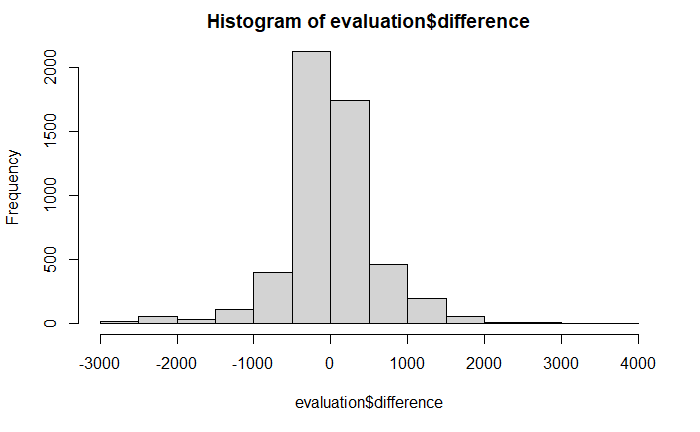

```r
hist(evaluation$difference)
```

Our RMSE of 581.6981 is relatively high even though we removed t2. Because of this, the model may not be the most accurate hence further research and understanding may be needed to train this model to better accuracy.